# New evidence of Neandertal butchery traditions through the marrow extraction in southwestern Europe (MIS 5-3)

Delphine Vettese, Antony Borel, Ruth Blasco, Louis Chevillard, Trajanka Stavrova, Ursula Thun Hohenstein, Marta Arzarello, Marie-Hélène Moncel, Camille Daujeard

The code below will allow you to reproduce the figures 9 to 14.

### **Run necessary packages and import data**

#### **Run required libraries**

```r
library(tidyverse)
library(readxl)
library(kableExtra)
library(knitr)
library(FactoMineR)
library(factoextra)
```

#### **Import data**

```r
data<-read_excel(path="dataFULL_Vettese.xlsx", sheet = "dataFULL_Vettese", range = "A1:H13381", col_names = TRUE)
data <- data %>%
  mutate_if(is.character, as.factor)
data$AreaFace <- factor(data$AreaFace, levels = c("p2a", "p3a", "p4a", "p2l", "p3l", "p4l", "p2p", "p3p", "p4p", "p2m", "p3m", "p4m"))

# Explore the first 100 rows of the dataset
data[1:100,] %>%
  kbl(align = c(rep("l", 4), rep("c", 12))) %>% #build table
  kable_classic("hover") %>% #classic table style
  column_spec(1, width_min = "5em")  %>% #specify first column width
  scroll_box(width = "900px", height = "200px") #specify table width and height
```

| Site | RefData | BoneElement | ImpactPresence | Area | Face | AreaFace | AreaFaceImpact |
| --- | --- | --- | --- | --- | --- | --- | --- |
| Bolomor | BOL-IV | Femur | nPM | p2 | a | p2a | p2a_nPM |
| Bolomor | BOL-IV | Femur | nPM | p2 | a | p2a | p2a_nPM |
| Bolomor | BOL-IV | Femur | nPM | p2 | a | p2a | p2a_nPM |
| Bolomor | BOL-IV | Femur | nPM | p2 | a | p2a | p2a_nPM |
| Bolomor | BOL-IV | Femur | nPM | p2 | a | p2a | p2a_nPM |
| Bolomor | BOL-IV | Femur | nPM | p2 | a | p2a | p2a_nPM |
| Bolomor | BOL-IV | Femur | nPM | p2 | a | p2a | p2a_nPM |
| Bolomor | BOL-IV | Femur | nPM | p2 | a | p2a | p2a_nPM |
| Bolomor | BOL-IV | Femur | nPM | p2 | a | p2a | p2a_nPM |
| Bolomor | BOL-IV | Femur | nPM | p2 | a | p2a | p2a_nPM |
| Bolomor | BOL-IV | Femur | nPM | p2 | a | p2a | p2a_nPM |
| Bolomor | BOL-IV | Femur | nPM | p2 | a | p2a | p2a_nPM |
| Bolomor | BOL-IV | Femur | nPM | p2 | a | p2a | p2a_nPM |
| Bolomor | BOL-XVIIa | Femur | nPM | p2 | a | p2a | p2a_nPM |
| Bolomor | BOL-XVIIa | Femur | nPM | p2 | a | p2a | p2a_nPM |
| Bolomor | BOL-XVIIa | Femur | nPM | p2 | a | p2a | p2a_nPM |
| Bolomor | BOL-XVIIa | Femur | nPM | p2 | a | p2a | p2a_nPM |
| Bolomor | BOL-XVIIa | Femur | nPM | p2 | a | p2a | p2a_nPM |
| Bolomor | BOL-XVIIa | Femur | nPM | p2 | a | p2a | p2a_nPM |
| Bolomor | BOL-XVIIa | Femur | nPM | p2 | a | p2a | p2a_nPM |
| Bolomor | BOL-XVIIc | Femur | nPM | p2 | a | p2a | p2a_nPM |
| Bolomor | BOL-XVIIc | Femur | nPM | p2 | a | p2a | p2a_nPM |
| Bolomor | BOL-XVIIc | Femur | nPM | p2 | a | p2a | p2a_nPM |
| Bolomor | BOL-XVIIc | Femur | nPM | p2 | a | p2a | p2a_nPM |
| Bolomor | BOL-IV | Humerus | nPM | p2 | a | p2a | p2a_nPM |
| Bolomor | BOL-IV | Humerus | nPM | p2 | a | p2a | p2a_nPM |
| Bolomor | BOL-IV | Humerus | nPM | p2 | a | p2a | p2a_nPM |
| Bolomor | BOL-IV | Humerus | nPM | p2 | a | p2a | p2a_nPM |
| Bolomor | BOL-IV | Humerus | nPM | p2 | a | p2a | p2a_nPM |
| Bolomor | BOL-IV | Humerus | nPM | p2 | a | p2a | p2a_nPM |

[output cut: 70 more lines]

### **Results**

#### **Percussion marks analysis**

##### Non-random and counter-intuitive distribution of percussion marks

```r
#### Data with and without percussion mark
data.activePMnPM <- data

#### Subset data with percussion mark only
data.activePM <- data.activePMnPM[data.activePMnPM$ImpactPresence=="PM",-4]

#### Subset data with percussion mark only for each bone element
data.activePM.Femur <- data.activePM[data.activePM$BoneElement=="Femur",-3]
data.activePM.Humerus <- data.activePM[data.activePM$BoneElement=="Humerus",-3]
data.activePM.Radius <- data.activePM[data.activePM$BoneElement=="Radius",-3]
data.activePM.Tibia <- data.activePM[data.activePM$BoneElement=="Tibia",-3]
data.activePM.Metacarpal <- data.activePM[data.activePM$BoneElement=="Metacarpal",-3]
data.activePM.Metatarsal <- data.activePM[data.activePM$BoneElement=="Metatarsal",-3]
```

##### *Humerus*

Number of areas with percussion marks for each archaeological site and for the intuitive experiment model for humerus. Portion 2 (P2): proximal diaphysis; Portion 3 (P3): medial diaphysis; Portion 4 (P4): distal diaphysis; sides: anterior (a), lateral (l), posterior (p) and medial (m). [Figure 9 of Vettese et al.]

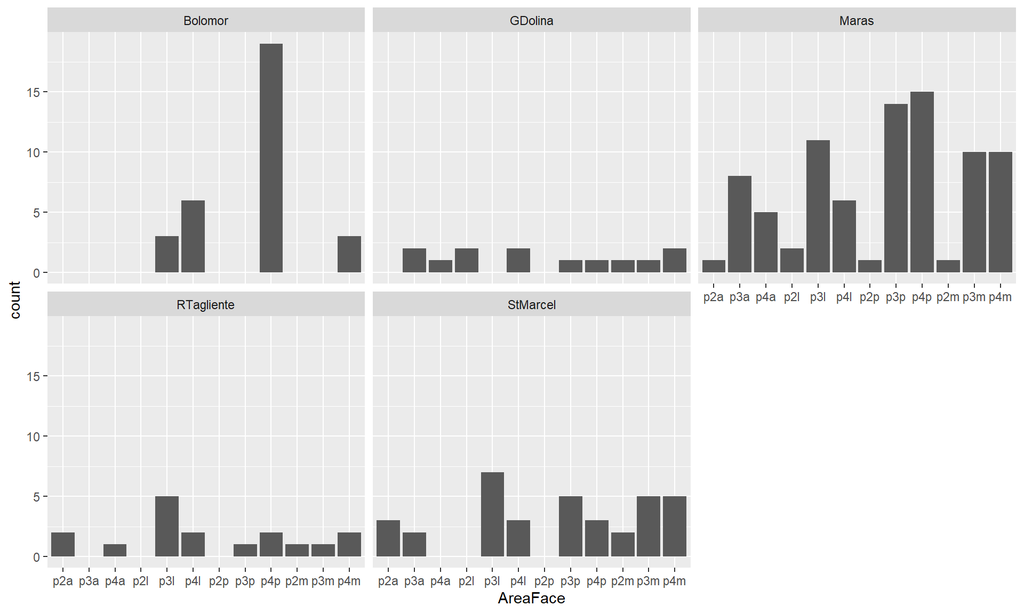

```r
## Remove data from Experiment
HumerusNoExpPM <- data.activePM.Humerus[data.activePM.Humerus$Site!="Experiment",]
HumerusNoExpPM$Site <- factor(HumerusNoExpPM$Site)
## AreaFace by Site PM, Experiment excluded
ArchHumerus <- ggplot(HumerusNoExpPM, aes(AreaFace, ..count..))+
  geom_bar(position = "dodge")+
  facet_wrap(~Site)
ArchHumerus
```

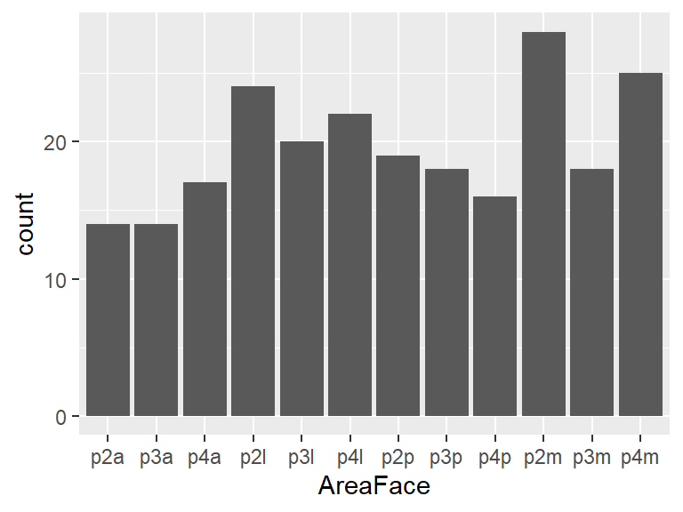

```r
## Extraction of the data from the intuitivity experiment for bone with percussion mark only
HumerusExpIntPM <- data.activePM.Humerus[data.activePM.Humerus$RefData=="Exp_Int",]
HumerusExpIntPM$RefData <- factor(HumerusExpIntPM$RefData)
# visualisation
ExpHumerus <- ggplot(HumerusExpIntPM, aes(AreaFace, ..count..))+
  geom_bar(position = "dodge")
ExpHumerus
```

##### *Radio-ulna*

Number of areas with percussion marks for each archaeological site and for the intuitive experiment model for radio-ulnas. Portion 2 (P2): proximal diaphysis; Portion 3 (P3): medial diaphysis; Portion 4 (P4): distal diaphysis; sides: anterior (a), lateral (l), posterior (p) and medial (m). [Figure 9 of Vettese et al.]

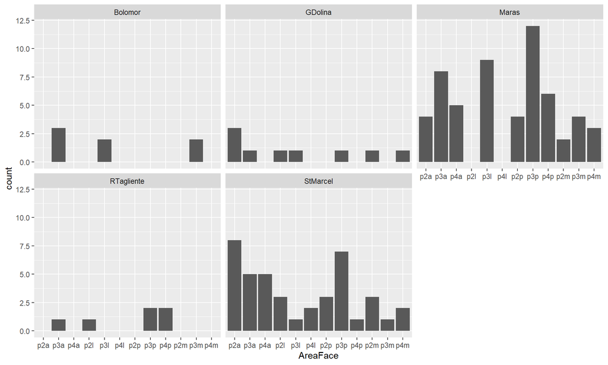

```r
## Remove data from Experiment
RadiusNoExpPM <- data.activePM.Radius[data.activePM.Radius$Site!="Experiment",]
RadiusNoExpPM$Site <- factor(RadiusNoExpPM$Site)
## AreaFace by Site PM, Experiment excluded
ArchRadius <- ggplot(RadiusNoExpPM, aes(AreaFace, ..count..))+
  geom_bar(position = "dodge")+
  facet_wrap(~Site)
ArchRadius
```

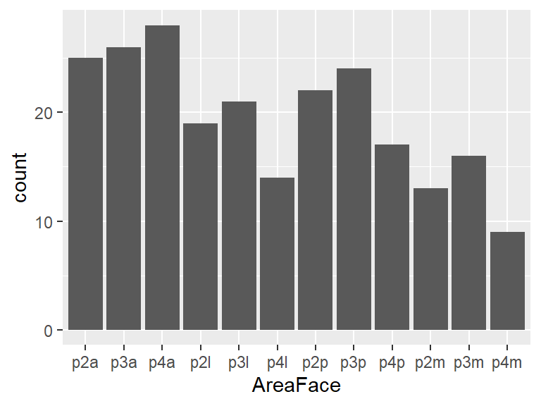

```r
## Extraction of the data from the intuitivity experiment for bone with percussion mark only
RadiusExpIntPM <- data.activePM.Radius[data.activePM.Radius$RefData=="Exp_Int",]
RadiusExpIntPM$RefData <- factor(RadiusExpIntPM$RefData)
# visualisation
ExpRadius <- ggplot(RadiusExpIntPM, aes(AreaFace, ..count..))+
  geom_bar(position = "dodge")
ExpRadius
```

##### *Femur*

Number of areas with percussion marks for each archaeological site and for the intuitive experiment model for femora. Portion 2 (P2): proximal diaphysis; Portion 3 (P3): medial diaphysis; Portion 4 (P4): distal diaphysis; sides: anterior (a), lateral (l), posterior (p) and medial (m). [Figure 10 of Vettese et al.]

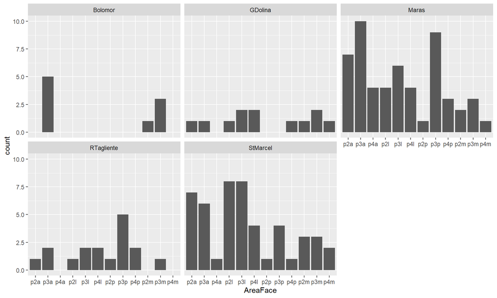

```r
## Remove data from Experiment
FemurNoExpPM <- data.activePM.Femur[data.activePM.Femur$Site!="Experiment",]
FemurNoExpPM$Site <- factor(FemurNoExpPM$Site)
## AreaFace by Site PM, Experiment excluded
ArchFemur <- ggplot(FemurNoExpPM, aes(AreaFace, ..count..))+
  geom_bar(position = "dodge")+
  facet_wrap(~Site)
ArchFemur
```

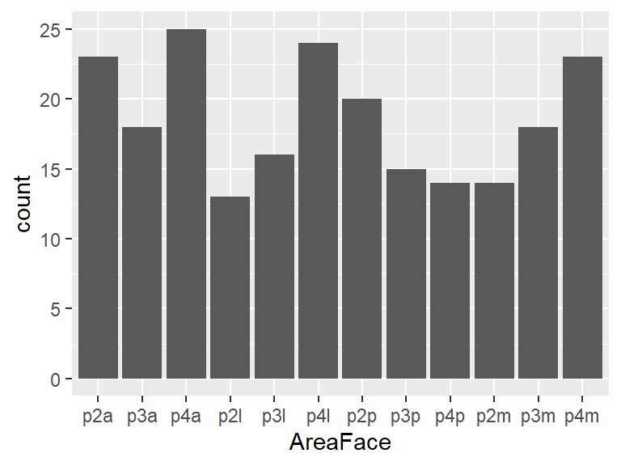

```r
## Extraction of the data from the intuitivity experiment for bone with percussion mark only
FemurExpIntPM <- data.activePM.Femur[data.activePM.Femur$RefData=="Exp_Int",]
FemurExpIntPM$RefData <- factor(FemurExpIntPM$RefData)
# visualisation
ExpFemur <- ggplot(FemurExpIntPM, aes(AreaFace, ..count..))+
  geom_bar(position = "dodge")
ExpFemur
```

##### *Tibia*

Number of areas with percussion marks for each archaeological site and for the intuitive experiment model for tibias. Portion 2 (P2): proximal diaphysis; Portion 3 (P3): medial diaphysis; Portion 4 (P4): distal diaphysis; sides: anterior (a), lateral (l), posterior (p) and medial (m). [Figure 10 of Vettese et al.]

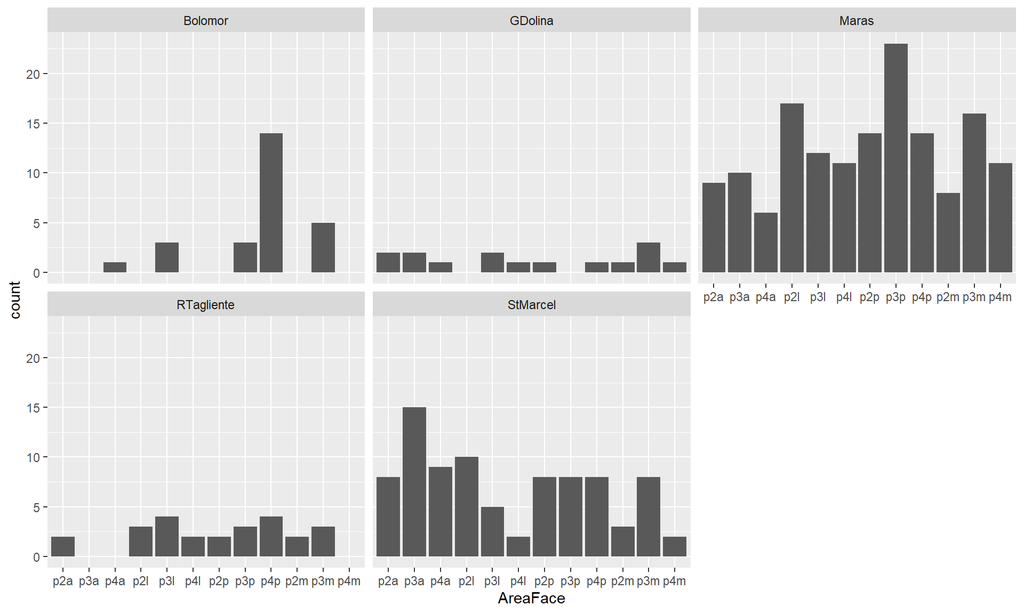

```r
## Remove data from Experiment
TibiaNoExpPM <- data.activePM.Tibia[data.activePM.Tibia$Site!="Experiment",]
TibiaNoExpPM$Site <- factor(TibiaNoExpPM$Site)
## AreaFace by Site PM, Experiment excluded
ArchTibia <- ggplot(TibiaNoExpPM, aes(AreaFace, ..count..))+
  geom_bar(position = "dodge")+
  facet_wrap(~Site)
ArchTibia
```

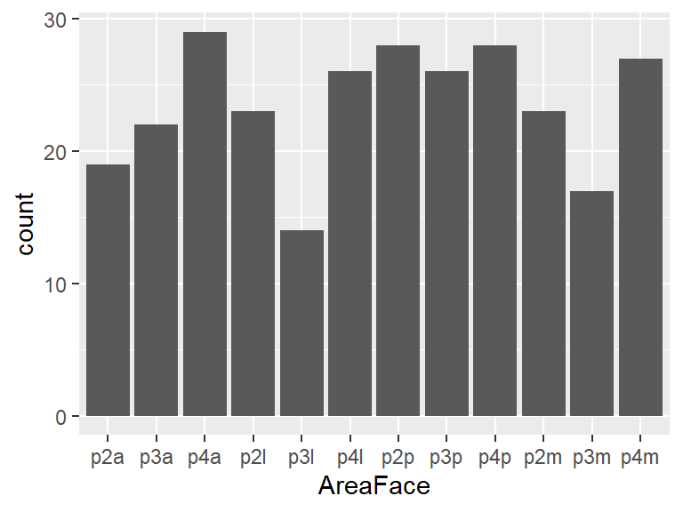

```r
## Extraction of the data from the intuitivity experiment for bone with percussion mark only
TibiaExpIntPM <- data.activePM.Tibia[data.activePM.Tibia$RefData=="Exp_Int",]
TibiaExpIntPM$RefData <- factor(TibiaExpIntPM$RefData)
# visualisation
ExpTibia <- ggplot(TibiaExpIntPM, aes(AreaFace, ..count..))+
  geom_bar(position = "dodge")
ExpTibia
```

##### *Metatarsal*

Number of areas with percussion marks for each archaeological site for metatarsals. Portion 2 (P2): proximal diaphysis; Portion 3 (P3): medial diaphysis; Portion 4 (P4): distal diaphysis; sides: anterior (a), lateral (l), posterior (p) and medial (m). [Figure 11 of Vettese et al.]

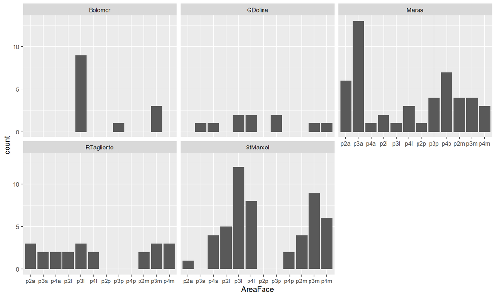

```r
## Remove data from Experiment
MetatarsalNoExpPM <- data.activePM.Metatarsal[data.activePM.Metatarsal$Site!="Experiment",]
MetatarsalNoExpPM$Site <- factor(MetatarsalNoExpPM$Site)
## AreaFace by Site PM, Experiment excluded
ArchMetatarsal <- ggplot(MetatarsalNoExpPM, aes(AreaFace, ..count..))+
  geom_bar(position = "dodge")+
  facet_wrap(~Site)
ArchMetatarsal
```

##### *Metacarpal*

Number of areas with percussion marks for each archaeological site for metacarpals. Portion 2 (P2): proximal diaphysis; Portion 3 (P3): medial diaphysis; Portion 4 (P4): distal diaphysis; sides: anterior (a), lateral (l), posterior (p) and medial (m). [Figure 11 of Vettese et al.]

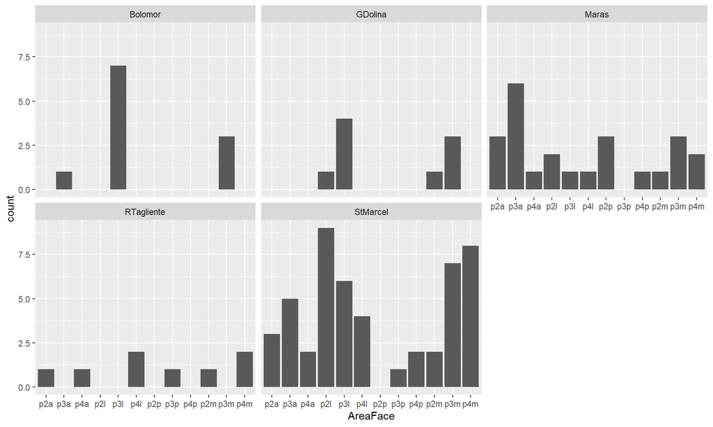

```r
## Remove data from Experiment
MetacarpalNoExpPM <- data.activePM.Metacarpal[data.activePM.Metacarpal$Site!="Experiment",]
MetacarpalNoExpPM$Site <- factor(MetacarpalNoExpPM$Site)
## AreaFace by Site PM, Experiment excluded
ArchMetacarpal <- ggplot(MetacarpalNoExpPM, aes(AreaFace, ..count..))+
  geom_bar(position = "dodge")+
  facet_wrap(~Site)
ArchMetacarpal
```

#### **Non-random and counter-intuitive distribution of percussion marks**

##### *Humerus*

MCA of the areas with percussion marks by bone portion and side for humerus. Sites are included as illustrative variable only. Cos² are displayed following a colour gradient. [Figure 12a and b of Vettese et al.]

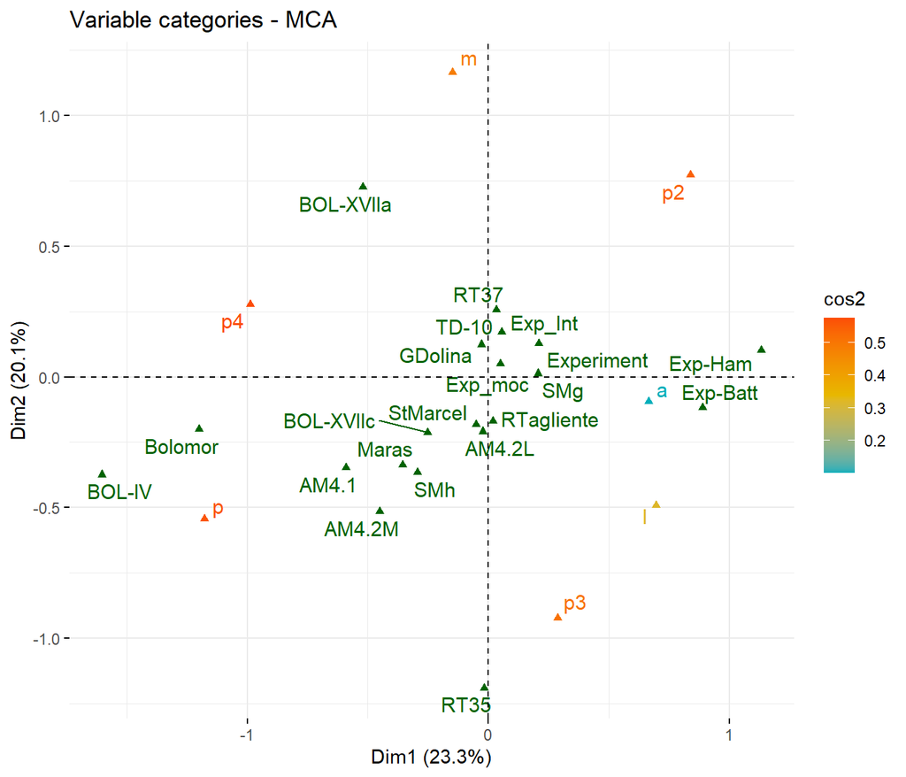

```r
## Compute MCA
Humerus.res.mca <- MCA(data.activePM.Humerus[, 1:4], ncp = 4, ind.sup = NULL, quanti.sup = NULL,
               quali.sup = c(1,2), excl=NULL, graph = FALSE,
               level.ventil = 0, axes = c(1,2), row.w = NULL,
               method="Indicator", na.method="NA", tab.disj=NULL)
## Color by cos2 values: quality on the factor map
fviz_mca_var(Humerus.res.mca, axes = c(1, 2), col.var = "cos2",
             gradient.cols = c("#00AFBB", "#E7B800", "#FC4E07"),
             repel = TRUE, # Avoid text overlapping
             ggtheme = theme_minimal())
```

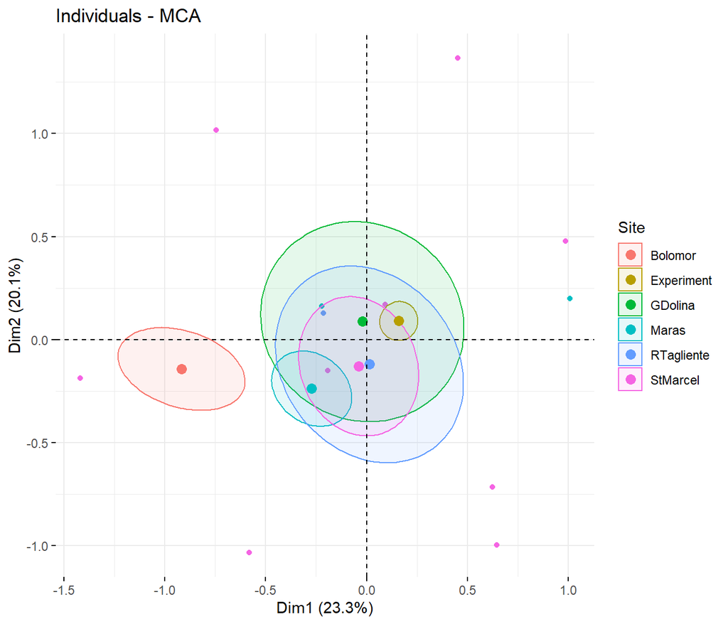

```r
# Color individuals by groups
fviz_mca_ind(Humerus.res.mca,
             label = "none", # hide individual labels
             habillage = "Site", # color by groups
             palette = "ngs",
             addEllipses = TRUE, ellipse.type = "confidence",
             ggtheme = theme_minimal())
```

##### *Radio-ulna*

MCA of the areas with percussion marks by bone portion and side for radio-ulna. Sites are included as illustrative variable only. Cos² are displayed following a colour gradient. [Figure 12 c and d of Vettese et al.]

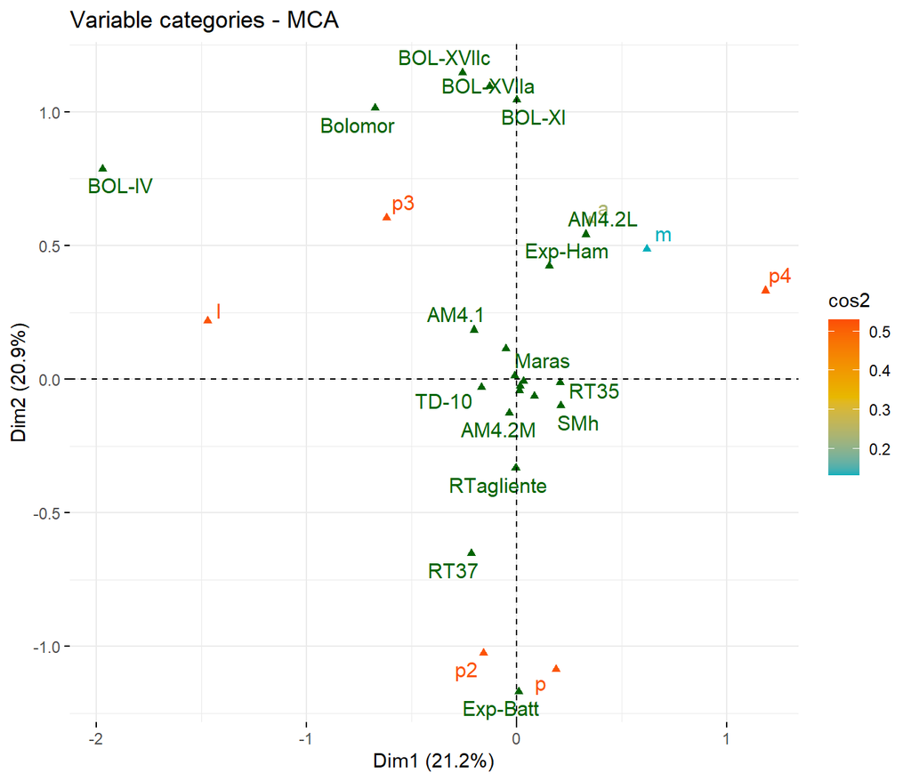

```r
## Compute MCA
Radius.res.mca <- MCA(data.activePM.Radius[, 1:4], ncp = 4, ind.sup = NULL, quanti.sup = NULL,
               quali.sup = c(1,2), excl=NULL, graph = FALSE,
               level.ventil = 0, axes = c(1,2), row.w = NULL,
               method="Indicator", na.method="NA", tab.disj=NULL)
## Color by cos2 values: quality on the factor map
fviz_mca_var(Radius.res.mca, axes = c(1, 2), col.var = "cos2",
             gradient.cols = c("#00AFBB", "#E7B800", "#FC4E07"),
             repel = TRUE, # Avoid text overlapping
             ggtheme = theme_minimal())
```

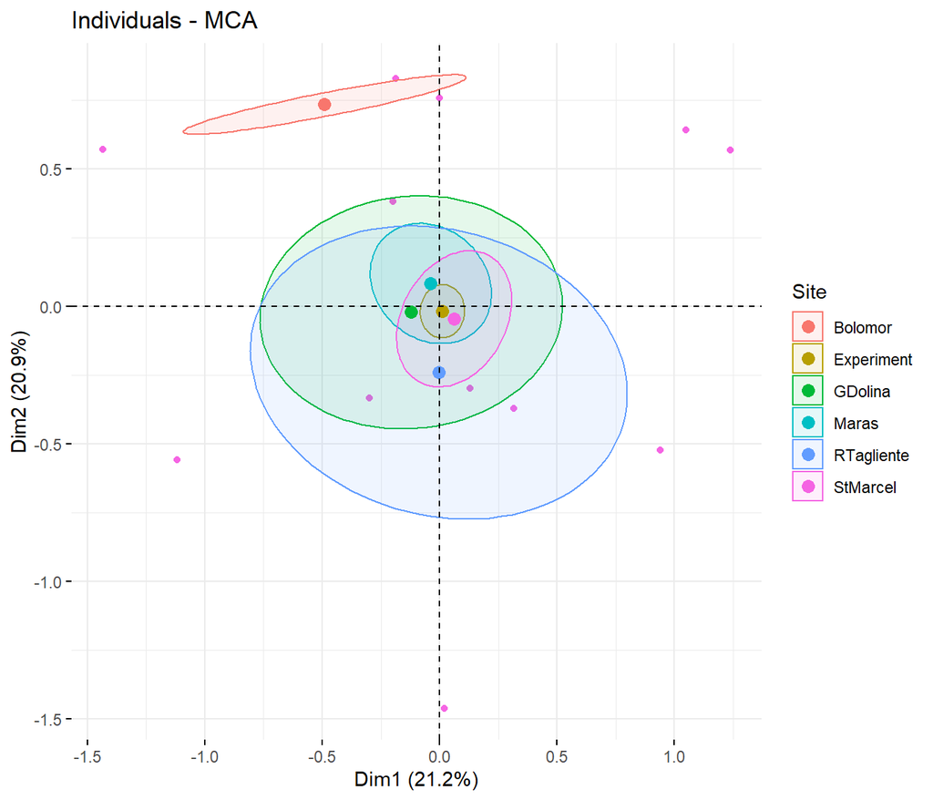

```r
# Color individuals by groups
fviz_mca_ind(Radius.res.mca,
             label = "none", # hide individual labels
             habillage = "Site", # color by groups
             palette = "ngs",
             addEllipses = TRUE, ellipse.type = "confidence",
             ggtheme = theme_minimal())
```

##### *Femur*

MCA of the areas with percussion marks by bone portion and side for femur. Sites are included as illustrative variable only. Cos² are displayed following a colour gradient. [Figure 13a and b of Vettese et al.]

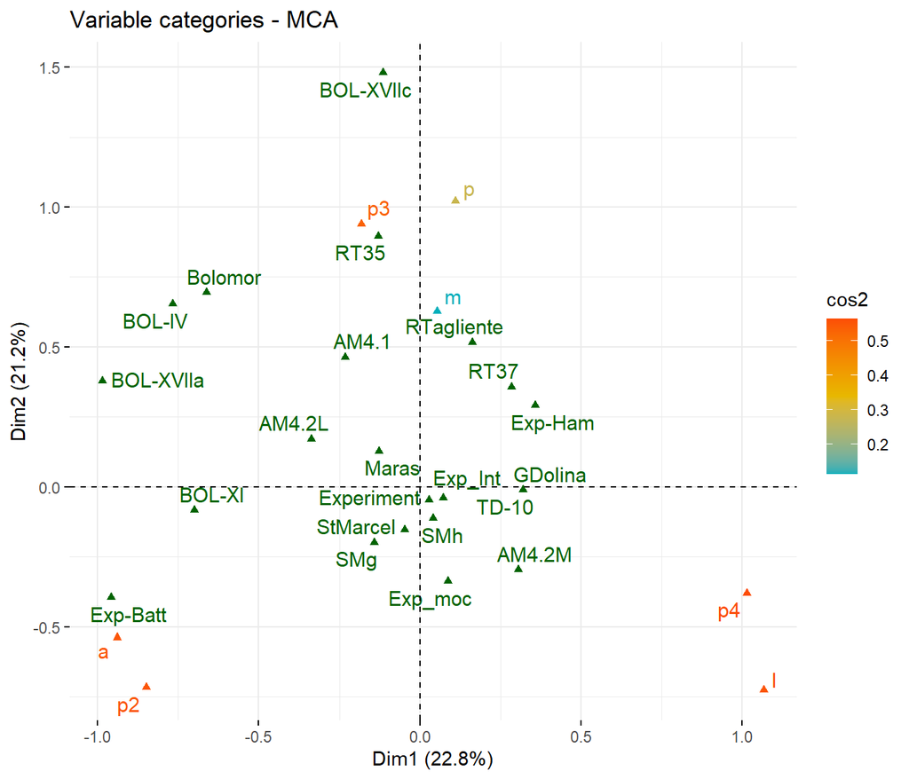

```r
## Compute MCA
Femur.res.mca <- MCA(data.activePM.Femur[, 1:4], ncp = 4, ind.sup = NULL, quanti.sup = NULL,
               quali.sup = c(1,2), excl=NULL, graph = FALSE,
               level.ventil = 0, axes = c(1,2), row.w = NULL,
               method="Indicator", na.method="NA", tab.disj=NULL)
## Color by cos2 values: quality on the factor map
fviz_mca_var(Femur.res.mca, axes = c(1, 2), col.var = "cos2",
             gradient.cols = c("#00AFBB", "#E7B800", "#FC4E07"),
             repel = TRUE, # Avoid text overlapping
             ggtheme = theme_minimal())
```

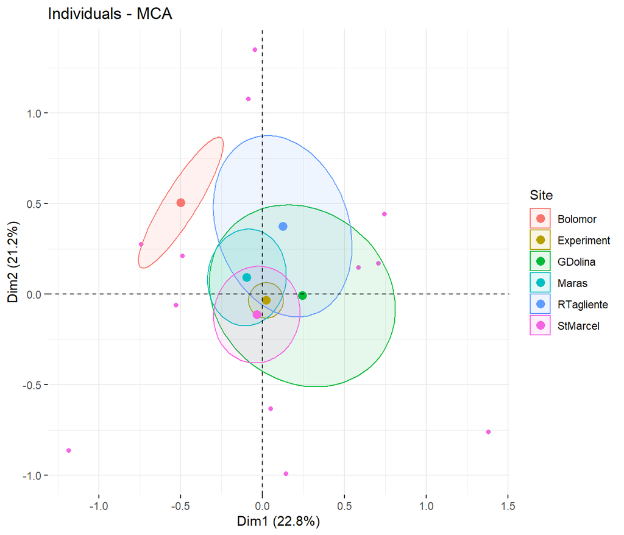

```r
# Color individuals by groups
fviz_mca_ind(Femur.res.mca,
             label = "none", # hide individual labels
             habillage = "Site", # color by groups
             palette = "ngs",
             addEllipses = TRUE, ellipse.type = "confidence",
             ggtheme = theme_minimal())
```

##### *Tibia*

MCA of the areas with percussion marks by bone portion and side for tibia. Sites are included as illustrative variable only. Cos² are displayed following a colour gradient. [Figure 13c and d of Vettese et al.]

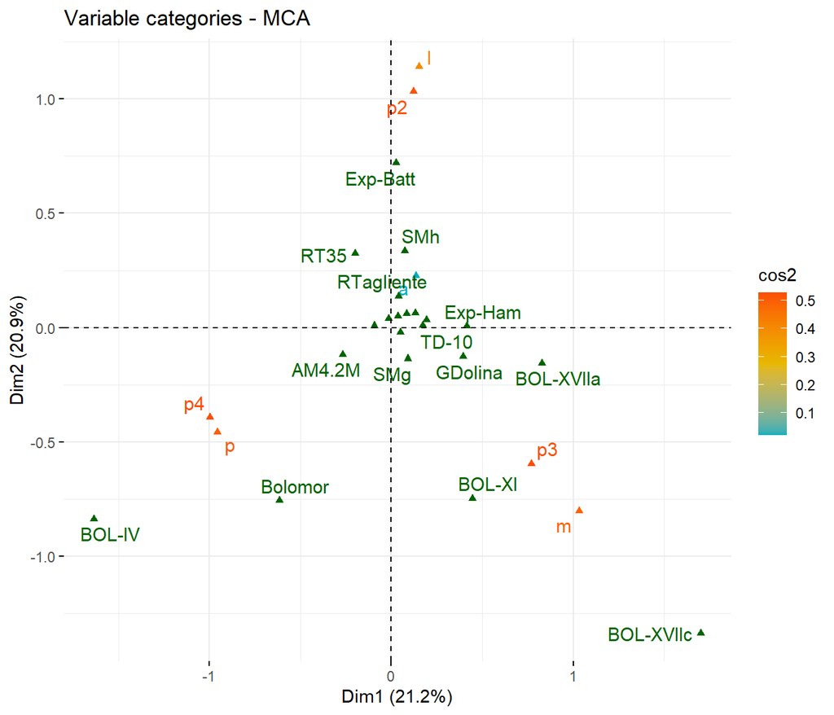

```r
## Compute MCA
Tibia.res.mca <- MCA(data.activePM.Tibia[, 1:4], ncp = 4, ind.sup = NULL, quanti.sup = NULL,
               quali.sup = c(1,2), excl=NULL, graph = FALSE,
               level.ventil = 0, axes = c(1,2), row.w = NULL,
               method="Indicator", na.method="NA", tab.disj=NULL)
## Color by cos2 values: quality on the factor map
fviz_mca_var(Tibia.res.mca, axes = c(1, 2), col.var = "cos2",
             gradient.cols = c("#00AFBB", "#E7B800", "#FC4E07"),
             repel = TRUE, # Avoid text overlapping
             ggtheme = theme_minimal())
```

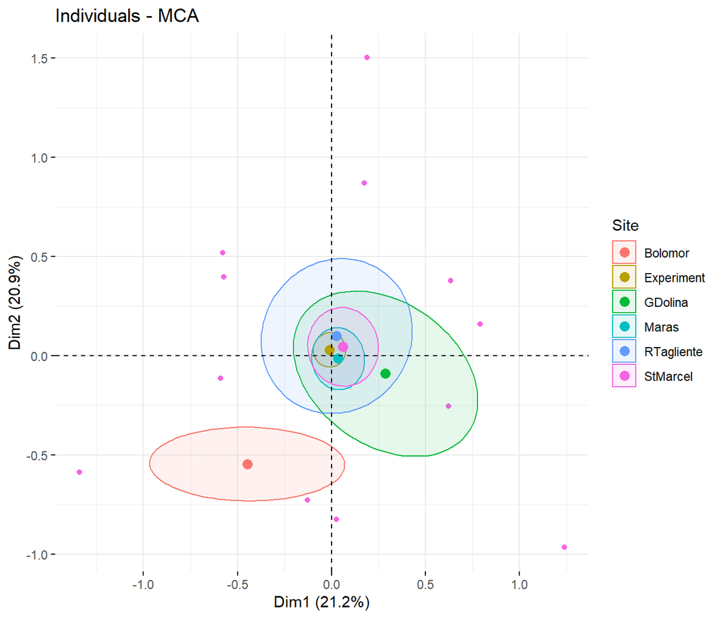

```r
# Color individuals by groups
fviz_mca_ind(Tibia.res.mca,
             label = "none", # hide individual labels
             habillage = "Site", # color by groups
             palette = "ngs",
             addEllipses = TRUE, ellipse.type = "confidence",
             ggtheme = theme_minimal())
```

##### *Metacarpal*

MCA of the areas with percussion marks by bone portion and side for metacarpal. Sites are included as illustrative variable only. Cos² are displayed following a colour gradient. [Figure 14a and b of Vettese et al.]

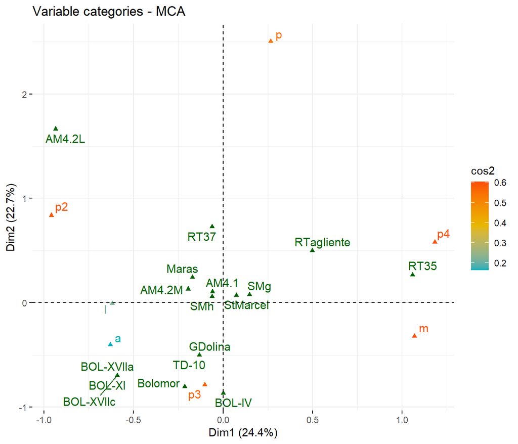

```r
## Compute MCA
Metacarpal.res.mca <- MCA(data.activePM.Metacarpal[, 1:4], ncp = 4, ind.sup = NULL, quanti.sup = NULL,
                          quali.sup = c(1,2), excl=NULL, graph = FALSE,
                          level.ventil = 0, axes = c(1,2), row.w = NULL,
                          method="Indicator", na.method="NA", tab.disj=NULL)
## Color by cos2 values: quality on the factor map
fviz_mca_var(Metacarpal.res.mca, axes = c(1, 2), col.var = "cos2",
             gradient.cols = c("#00AFBB", "#E7B800", "#FC4E07"),
             repel = TRUE, # Avoid text overlapping
             ggtheme = theme_minimal())
```

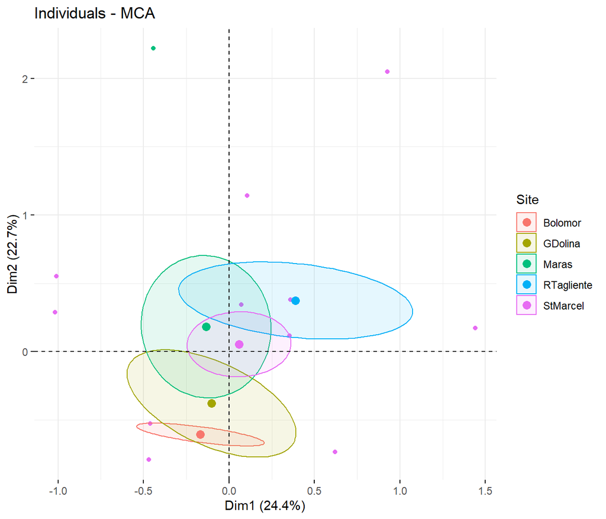

```r
# Color individuals by groups
fviz_mca_ind(Metacarpal.res.mca,
             label = "none", # hide individual labels
             habillage = "Site", # color by groups
             palette = "ngs",
             addEllipses = TRUE, ellipse.type = "confidence",
             ggtheme = theme_minimal())
```

##### *Metatarsal*

MCA of the areas with percussion marks by bone portion and side for metatarsal. Sites are included as illustrative variable only. Cos² are displayed following a colour gradient. [Figure 14c and d of Vettese et al.]

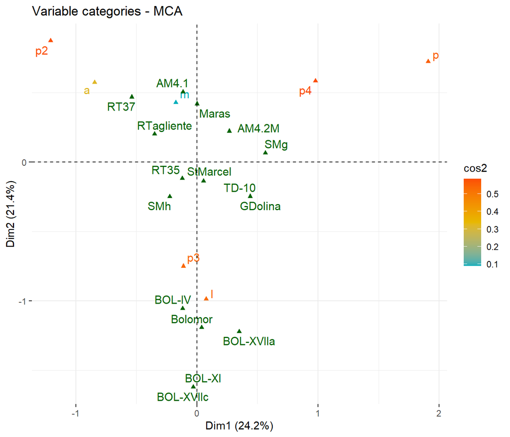

```r
## Compute MCA
Metatarsal.res.mca <- MCA(data.activePM.Metatarsal[, 1:4], ncp = 4, ind.sup = NULL, quanti.sup = NULL,
               quali.sup = c(1,2), excl=NULL, graph = FALSE,
               level.ventil = 0, axes = c(1,2), row.w = NULL,
               method="Indicator", na.method="NA", tab.disj=NULL)
## Color by cos2 values: quality on the factor map
fviz_mca_var(Metatarsal.res.mca, axes = c(1, 2), col.var = "cos2",
             gradient.cols = c("#00AFBB", "#E7B800", "#FC4E07"),
             repel = TRUE, # Avoid text overlapping
             ggtheme = theme_minimal())
```

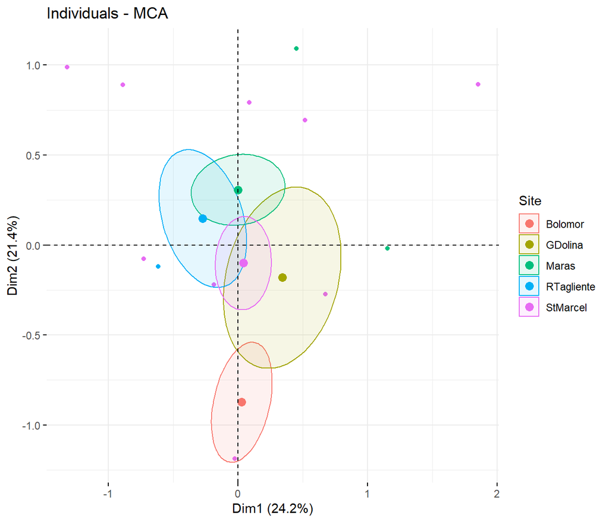

```r
# Color individuals by groups
fviz_mca_ind(Metatarsal.res.mca,
             label = "none", # hide individual labels
             habillage = "Site", # color by groups
             palette = "ngs",
             addEllipses = TRUE, ellipse.type = "confidence",
             ggtheme = theme_minimal())
```